# Predicting Mice Tendicies through Stimulation

```r
spks = as.numeric(unlist(s16$spks))
time = as.numeric(unlist(s16$time))
brain_area = data.frame(s16$brain_area)
brain_area %>% count(s16$brain_area, sort = TRUE)
```

```
##   s16$brain_area   n
## 1             TH 159
## 2            SSs 120
## 3             MB  77
## 4            LGd  73
## 5            SSp  24
## 6            CA3  21
```

```r
df = data.frame(spks, time,  contrast_left = s16$contrast_left, contrast_right = s16$contrast_right, feedback_type = s16$feedback_type)
count(df, spks)
```

```
##   spks       n
## 1    0 5175317
## 2    1  127884
## 3    2    5304
## 4    3     269
## 5    4      23
## 6    5       3
```

```r
mean(spks)
```

```
## [1] 0.02625942
```

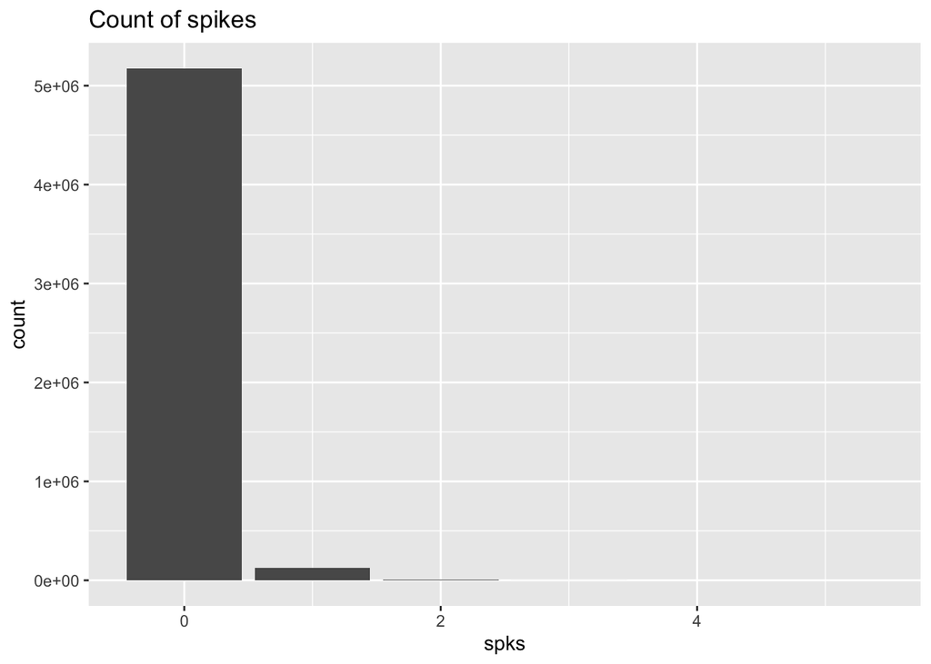

```r
ggplot(df) + geom_bar(mapping = aes(x=spks)) + labs(title = "Count of spikes")
```

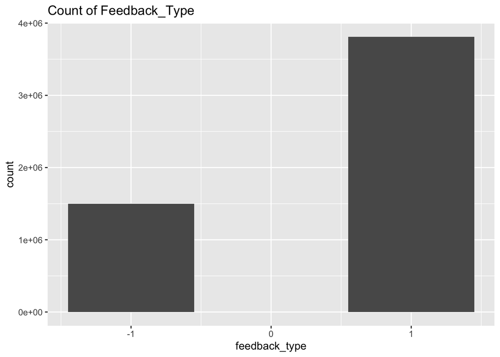

```r
ggplot(df) + geom_bar(mapping = aes(x=feedback_type)) + labs(title = "Count of Feedback_Type")
```

# Session 17: The most common brain_area was root with 358. With the average spikes at 0.029. There were more success in this session than failures. The mice name was Lederberg.

```r
s17 = session[[17]]
summary(s17)
```

```
##                Length Class  Mode
## contrast_left  224    -none- numeric
## contrast_right 224    -none- numeric
## feedback_type  224    -none- numeric
## mouse_name       1    -none- character
## brain_area     565    -none- character
## date_exp         1    -none- character
## spks           224    -none- list
## time           224    -none- list
```

```r
spks = as.numeric(unlist(s17$spks))
time = as.numeric(unlist(s17$time))
brain_area = data.frame(s17$brain_area)
brain_area %>% count(s17$brain_area, sort = TRUE)
```

```
##   s17$brain_area   n
## 1           root 358
## 2            VPM  60
## 3            VPL  50
## 4             RT  44
## 5            MEA  41
## 6             LD  12
```

```r
df = data.frame(spks, time, contrast_left = s17$contrast_left, contrast_right = s17$contrast_right, feedback_type = s17$feedback_type)
count(df, spks)
```

```
##   spks       n
## 1    0 4925832
## 2    1  126819
## 3    2    8654
## 4    3     967
## 5    4     123
## 6    5       5
```

```r
mean(spks)
```

```
## [1] 0.02914527
```

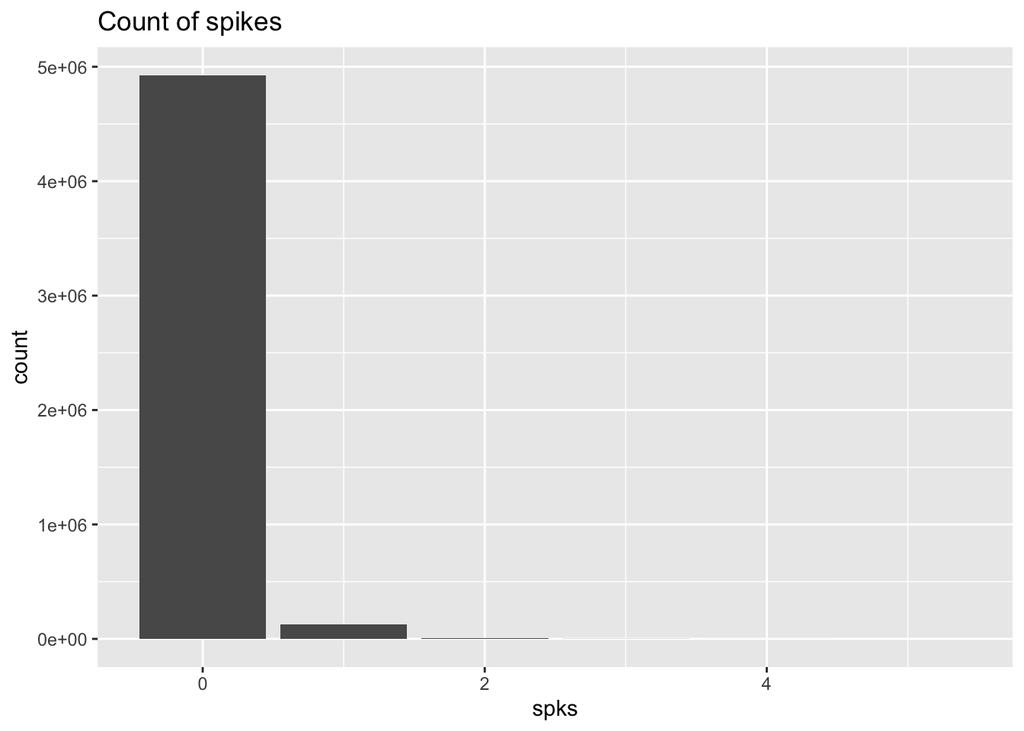

```r
ggplot(df) + geom_bar(mapping = aes(x=spks)) + labs(title = "Count of spikes")
```

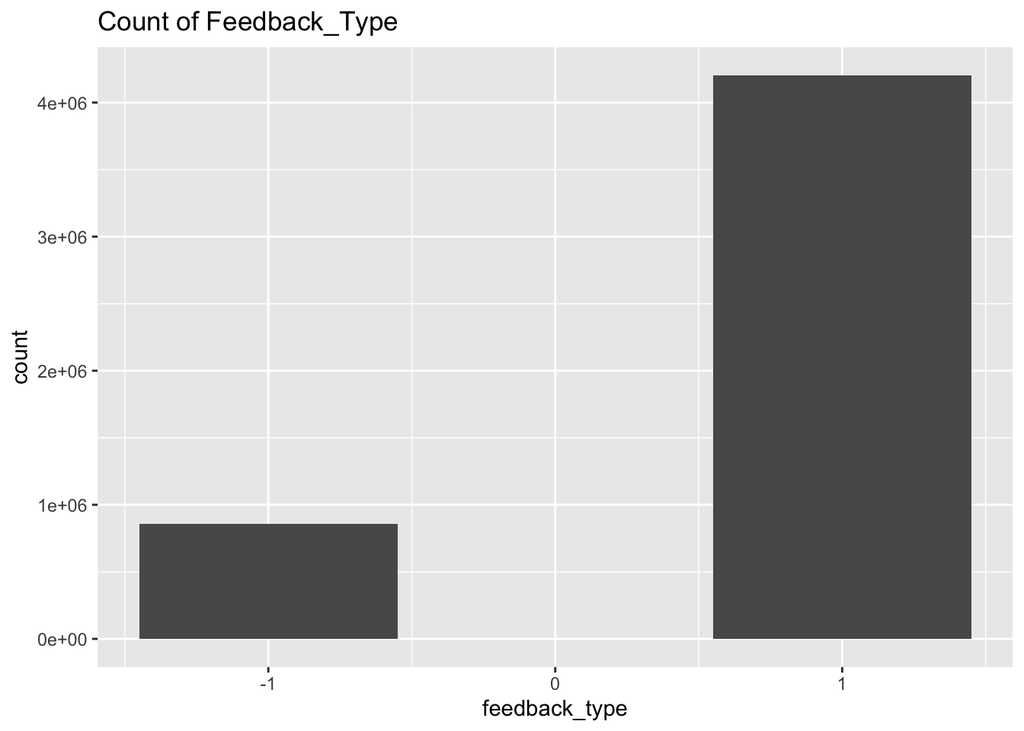

```r
ggplot(df) + geom_bar(mapping = aes(x=feedback_type)) + labs(title = "Count of Feedback_Type")
```

# Session 18: The most common brain_area was TH and ZI with 175. With the average spikes at 0.027. There were more success in this session than failures. The mice name was Lederberg.

```r
s18 = session[[18]]
summary(s18)
```

```
##                Length Class  Mode
## contrast_left   216   -none- numeric
## contrast_right  216   -none- numeric
## feedback_type   216   -none- numeric
## mouse_name        1   -none- character
## brain_area     1090   -none- character
## date_exp          1   -none- character
## spks            216   -none- list
## time            216   -none- list
```

```r
spks = as.numeric(unlist(s18$spks))
time = as.numeric(unlist(s18$time))
brain_area = data.frame(s18$brain_area)
brain_area %>% count(s18$brain_area, sort = TRUE)
```

```
##    s18$brain_area   n
## 1              TH 175
## 2              ZI 175
## 3              CP 158
## 4             ACB 155
## 5             SNr 130
## 6            root  99
## 7             LGd  89
## 8              SI  48
## 9             CA3  35
## 10             OT  26
```

```r
df = data.frame(spks, time, contrast_left = s18$contrast_left, contrast_right = s18$contrast_right, feedback_type = s18$feedback_type)
count(df, spks)
```

```
##   spks       n
## 1    0 9175843
## 2    1  226761
## 3    2   13751
## 4    3    1122
## 5    4     101
## 6    5      19
## 7    6       3
```

```r
mean(spks)
```

```
## [1] 0.02741102
```

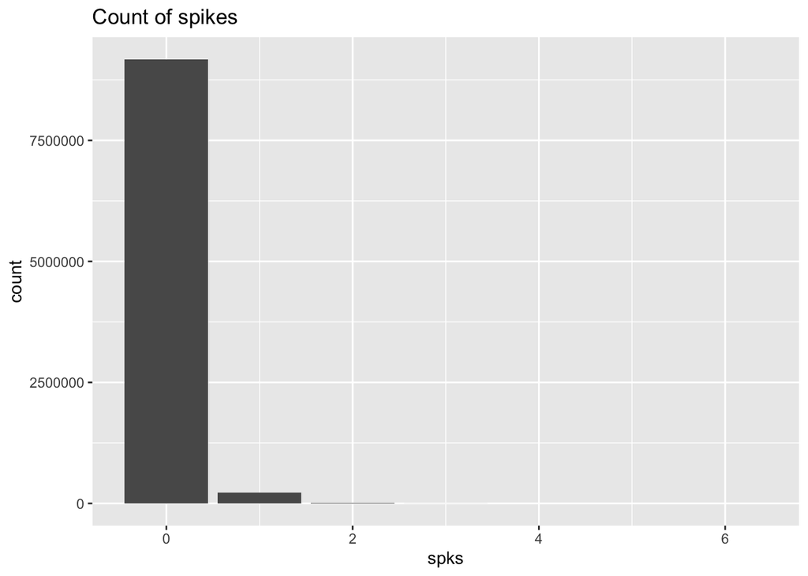

```r
ggplot(df) + geom_bar(mapping = aes(x=spks)) + labs(title = "Count of spikes")
```

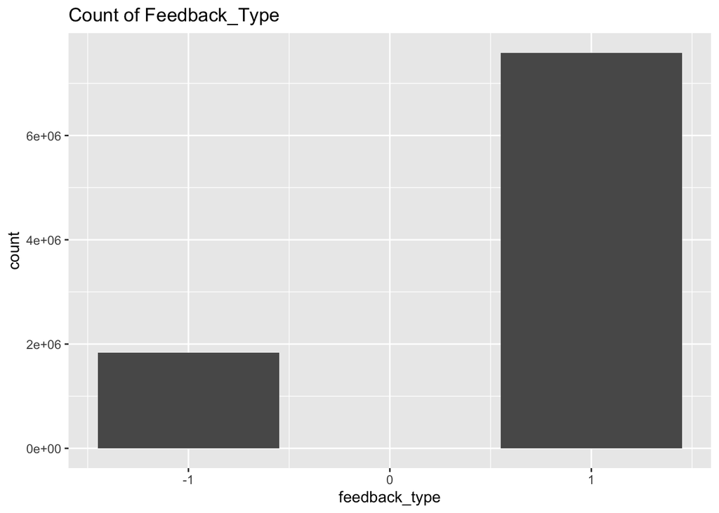

```r
ggplot(df) + geom_bar(mapping = aes(x=feedback_type)) + labs(title = "Count of Feedback_Type")
```

# Data Integration:

```r
dats = tibble()
for (x in 1:18) {
brain_area = data.frame(session[[x]]$brain_area)

}

for (i in 1:18) {
    n_obs = length(session[[i]]$feedback_type)


    dat = tibble(feedback_type = as.factor(session[[i]]$feedback_type), decision = rep('name', n_obs), avg_spikes = rep(0, n_obs)
    )

    for (j in 1:n_obs){

        if (session[[i]]$contrast_left[j] > session[[i]]$contrast_right[j]){
            dat$decision[j] = '1'
        } else if (session[[i]]$contrast_left[j] < session[[i]]$contrast_right[j]){
            dat$decision[i] = '2'
        } else if (session[[i]]$contrast_left[j] == session[[i]]$contrast_right[j]
                   & session[[i]]$contrast_left[j] == 0){
            dat$decision[j] = '3'
        } else{
            dat$decision[j] = '4'
        }
        spks.trial = session[[i]]$spks[[j]]
        total.spikes = apply(spks.trial, 1, sum)
        dat$avg_spikes[j] = mean(total.spikes)
    }

    dat$decision = as.factor(dat$decision)
    dats = bind_rows(dats, dat)
}

summary(dats)
```

```
##  feedback_type decision      avg_spikes
##  -1:1473       1   :1758   Min.   :0.4465
##  1 :3608       2   :  18   1st Qu.:1.0232
##                3   :1367   Median :1.2851
##                4   : 314   Mean   :1.3705
##                name:1624   3rd Qu.:1.6406
##                            Max.   :2.9715
```

# Predictive Modeling

```r
set.seed(101)
sam = sample.int(n = n_obs, size = floor(.8 * n_obs), replace = F)
train = dats[sam, ]
test = dats[-sam,]
fit1 = glm(feedback_type~., data = train, family="binomial")
summary(fit1)
```

```
##
## Call:
## glm(formula = feedback_type ~ ., family = "binomial", data = train)
##
## Coefficients:
##              Estimate Std. Error z value Pr(>|z|)
## (Intercept)   -1.8844     1.1373  -1.657   0.0975 .
## decision2     14.8726   982.1144   0.015   0.9879
## decision3     -0.2270     0.4827  -0.470   0.6382
## decision4     -0.7757     0.6339  -1.224   0.2211
## decisionname  -0.5849     0.4330  -1.351   0.1767
## avg_spikes     2.0542     0.7670   2.678   0.0074 **
## ---
## Signif. codes:  0 '***' 0.001 '**' 0.01 '*' 0.05 '.' 0.1 ' ' 1
##
## (Dispersion parameter for binomial family taken to be 1)
##
##     Null deviance: 221.20  on 171  degrees of freedom
## Residual deviance: 207.99  on 166  degrees of freedom
## AIC: 219.99
##
## Number of Fisher Scoring iterations: 14
```

```r
pred = predict(fit1, test %>% select(-feedback_type), type = 'response')
prediction1 = factor(pred > 0.5, labels = c('-1', '1'))
mean(prediction1 != test$feedback_type)
```

```
## [1] 0.3685068
```

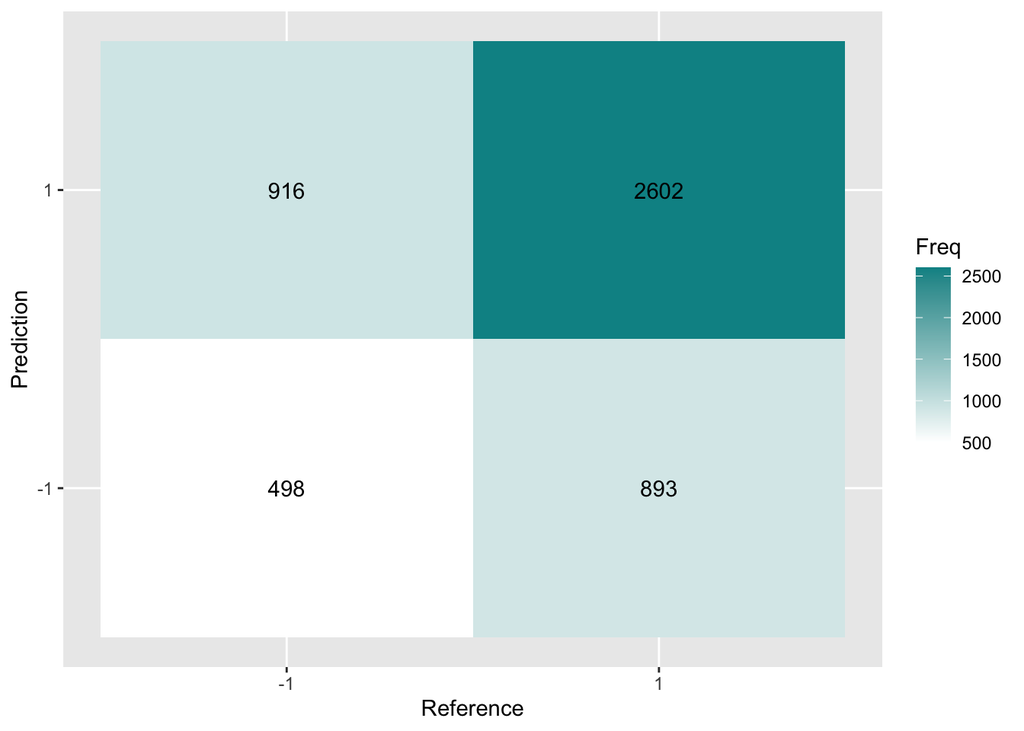

```r
cm = confusionMatrix(prediction1, test$feedback_type, dnn = c("Prediction", "Reference"))

plt = as.data.frame(cm$table)

ggplot(plt, aes(Reference, Prediction, fill= Freq)) +
        geom_tile() + geom_text(aes(label=Freq)) +
        scale_fill_gradient(low="white", high="#009194") +
        labs(x = "Reference",y = "Prediction") +
        scale_x_discrete(labels=c("-1","1")) +
        scale_y_discrete(labels=c("-1","1"))
```

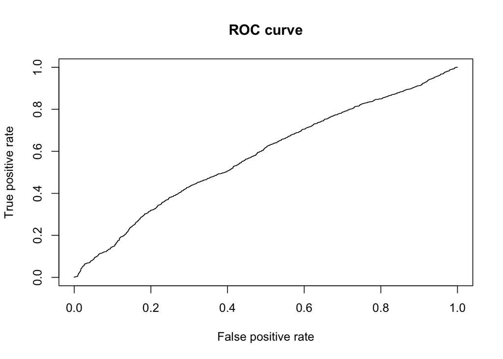

```r
pr = prediction(pred, test$feedback_type)
prf = performance(pr, measure = "tpr", x.measure = "fpr")
plot(prf, main = 'ROC curve')
```

# Test Data

Downloaded the test data which include 2 test data RDS files. Added a decision tree to see the difference between logistic regression and decision tree.

```r
  testdata=list()
  for(i in 1:2){
    testdata[[i]]=readRDS(paste('./Test/test',i,'.rds',sep=''))
    #print(session[[i]]$mouse_name)
    #print(session[[i]]$date_exp)
  }

summary(testdata[[1]])
```

```
##                Length Class  Mode
## contrast_left  100    -none- numeric
## contrast_right 100    -none- numeric
## feedback_type  100    -none- numeric
## mouse_name       1    -none- character
## brain_area     734    -none- character
## date_exp         1    -none- character
## spks           100    -none- list
## time           100    -none- list
```

```r
summary(testdata[[2]])
```

```
##                Length Class  Mode
## contrast_left   100   -none- numeric
## contrast_right  100   -none- numeric
## feedback_type   100   -none- numeric
## mouse_name        1   -none- character
## brain_area     1090   -none- character
## date_exp          1   -none- character
## spks            100   -none- list
## time            100   -none- list
```

```r
dats = tibble()
for (x in 1:2) {
brain_area = data.frame(testdata[[x]]$brain_area)
}

for (i in 1:2) {
    n_obs = length(testdata[[i]]$feedback_type)


    dat = tibble(feedback_type = as.factor(testdata[[i]]$feedback_type), decision = rep('name', n_obs), avg_spikes = rep(0, n_obs)
    )

    for (j in 1:n_obs){

        if (testdata[[i]]$contrast_left[j] > testdata[[i]]$contrast_right[j]){
            dat$decision[j] = '1'
        } else if (testdata[[i]]$contrast_left[j] < testdata[[i]]$contrast_right[j]){
            dat$decision[i] = '2'
        } else if (testdata[[i]]$contrast_left[j] == testdata[[i]]$contrast_right[j]
                   & testdata[[i]]$contrast_left[j] == 0){
            dat$decision[j] = '3'
        } else{
            dat$decision[j] = '4'
        }
        spks.trial = testdata[[i]]$spks[[j]]
        total.spikes = apply(spks.trial, 1, sum)
        dat$avg_spikes[j] = mean(total.spikes)
    }

    dat$decision = as.factor(dat$decision)
    dats = bind_rows(dats, dat)
}
summary(dats)
```

```
##  feedback_type decision    avg_spikes
##  -1: 55        1   :69   Min.   :0.6468
##  1 :145        2   : 2   1st Qu.:1.0853
##                3   :53   Median :1.2468
##                4   : 8   Mean   :1.2943
##                name:68   3rd Qu.:1.4656
##                          Max.   :2.2234
```

```r
set.seed(101)
sam = sample.int(n = n_obs, size = floor(.8 * n_obs), replace = F)
train = dats[sam, ]
test = dats[-sam,]
fit1 = glm(feedback_type~., data = train, family="binomial")
summary(fit1)
```

```
##
## Call:
## glm(formula = feedback_type ~ ., family = "binomial", data = train)
##
## Coefficients:
##               Estimate Std. Error z value Pr(>|z|)
## (Intercept)    -8.1950     2.9397  -2.788 0.005309 **
## decision2     -16.8457  1455.3977  -0.012 0.990765
## decision3       0.9588     0.9954   0.963 0.335413
## decision4      -3.3083     1.5600  -2.121 0.033954 *
## decisionname   -0.8066     0.8355  -0.965 0.334339
## avg_spikes      6.6106     2.0001   3.305 0.000949 ***
## ---
## Signif. codes:  0 '***' 0.001 '**' 0.01 '*' 0.05 '.' 0.1 ' ' 1
##
## (Dispersion parameter for binomial family taken to be 1)
##
##     Null deviance: 94.107  on 79  degrees of freedom
## Residual deviance: 66.538  on 74  degrees of freedom
## AIC: 78.538
##
## Number of Fisher Scoring iterations: 14
```

```r
pred = predict(fit1, test %>% select(-feedback_type), type = 'response')
prediction1 = factor(pred > 0.5, labels = c('-1', '1'))
mean(prediction1 != test$feedback_type)
```

```
## [1] 0.7
```

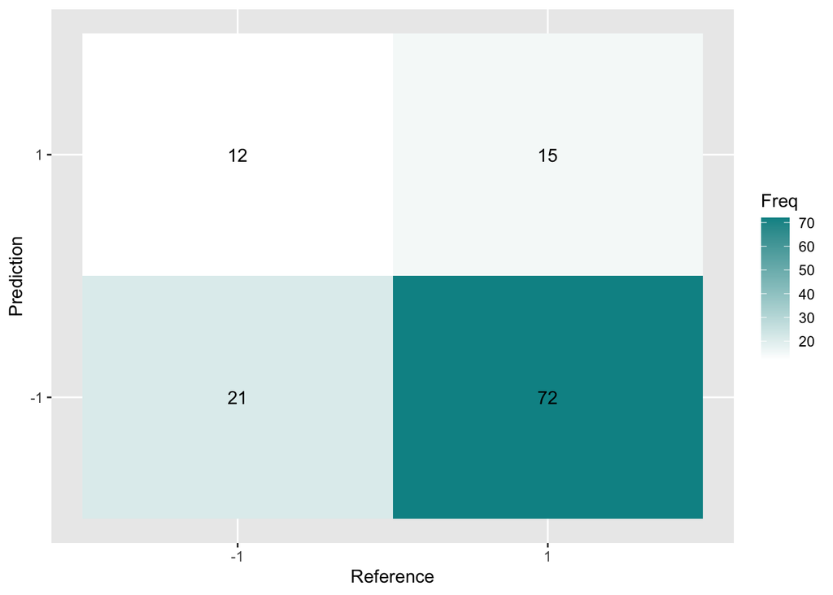

```r
cm = confusionMatrix(prediction1, test$feedback_type, dnn = c("Prediction", "Reference"))

plt = as.data.frame(cm$table)

ggplot(plt, aes(Reference, Prediction, fill= Freq)) +
        geom_tile() + geom_text(aes(label=Freq)) +
        scale_fill_gradient(low="white", high="#009194") +
        labs(x = "Reference",y = "Prediction") +
        scale_x_discrete(labels=c("-1","1")) +
        scale_y_discrete(labels=c("-1","1"))
```

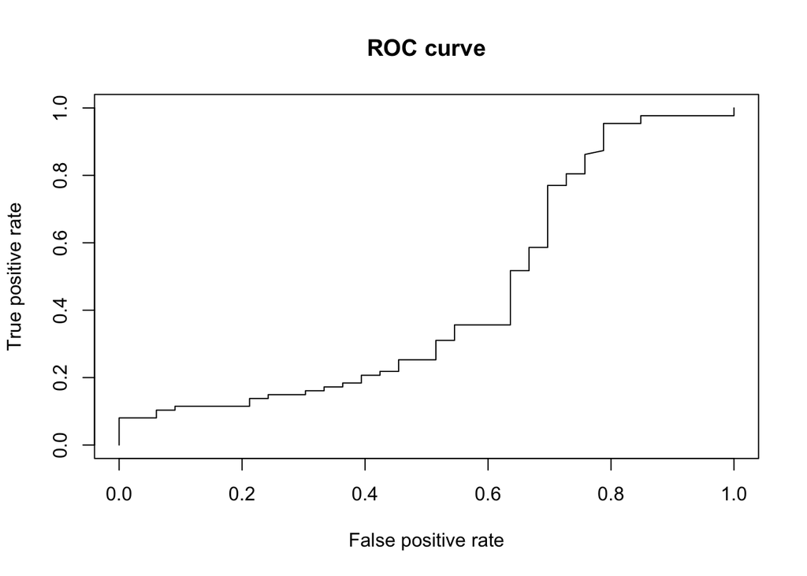

```r
pr = prediction(pred, test$feedback_type)
prf = performance(pr, measure = "tpr", x.measure = "fpr")
plot(prf, main = 'ROC curve')
```

```r
fit_tree <- rpart(feedback_type ~ ., data = train, method = "class")
summary(fit_tree)
```

```
## Call:
## rpart(formula = feedback_type ~ ., data = train, method = "class")
##   n= 80
##
##          CP nsplit rel error    xerror      xstd
## 1 0.1590909      0 1.0000000 1.0000000 0.1815339
## 2 0.0100000      2 0.6818182 0.8636364 0.1730111
##
## Variable importance
## avg_spikes   decision
##         68         32
##
## Node number 1: 80 observations,    complexity param=0.1590909
##   predicted class=1   expected loss=0.275  P(node) =1
##     class counts:    22    58
##    probabilities: 0.275 0.725
##   left son=2 (36 obs) right son=3 (44 obs)
##   Primary splits:
##       avg_spikes < 1.44346  to the left,  improve=8.364646, (0 missing)
##       decision   splits as  RLRLL,        improve=2.934921, (0 missing)
##   Surrogate splits:
##       decision splits as  RLLRL, agree=0.675, adj=0.278, (0 split)
##
## Node number 2: 36 observations,    complexity param=0.1590909
##   predicted class=-1  expected loss=0.4722222  P(node) =0.45
##     class counts:    19    17
##    probabilities: 0.528 0.472
##   left son=4 (19 obs) right son=5 (17 obs)
##   Primary splits:
##       decision   splits as  RLRLL,        improve=1.969212, (0 missing)
##       avg_spikes < 1.281335 to the right, improve=1.969212, (0 missing)
##   Surrogate splits:
##       avg_spikes < 1.288147 to the right, agree=0.75, adj=0.471, (0 split)
##
## Node number 3: 44 observations
##   predicted class=1   expected loss=0.06818182  P(node) =0.55
##     class counts:     3    41
##    probabilities: 0.068 0.932
##
## Node number 4: 19 observations
##   predicted class=-1  expected loss=0.3157895  P(node) =0.2375
##     class counts:    13     6
##    probabilities: 0.684 0.316
##
## Node number 5: 17 observations
##   predicted class=1   expected loss=0.3529412  P(node) =0.2125
##     class counts:     6    11
##    probabilities: 0.353 0.647
```

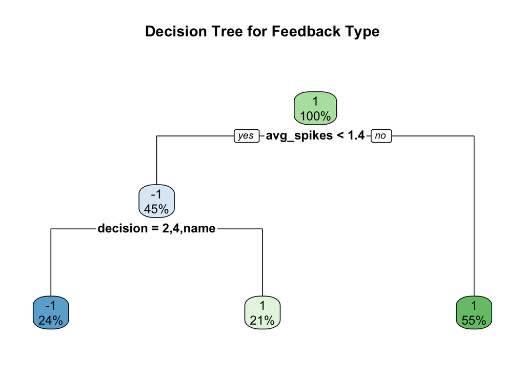

```r
rpart.plot(fit_tree, type = 2, extra = 100, main = "Decision Tree for Feedback Type")
```

```r
pred_tree <- predict(fit_tree, test, type = "class")
cm_tree <- confusionMatrix(pred_tree, test$feedback_type, dnn = c("Prediction", "Reference"))
print(cm_tree)
```

```
## Confusion Matrix and Statistics
##
##           Reference
## Prediction -1  1
##         -1  5 31
##         1  28 56
##
##                Accuracy : 0.5083
##                  95% CI : (0.4155, 0.6007)
##     No Information Rate : 0.725
##     P-Value [Acc > NIR] : 1.0000
##
##                   Kappa : -0.1992
##
##  Mcnemar's Test P-Value : 0.7946
##
##             Sensitivity : 0.15152
##             Specificity : 0.64368
##          Pos Pred Value : 0.13889
##          Neg Pred Value : 0.66667
##              Prevalence : 0.27500
##          Detection Rate : 0.04167
##    Detection Prevalence : 0.30000
##       Balanced Accuracy : 0.39760
##
##        'Positive' Class : -1
##
```

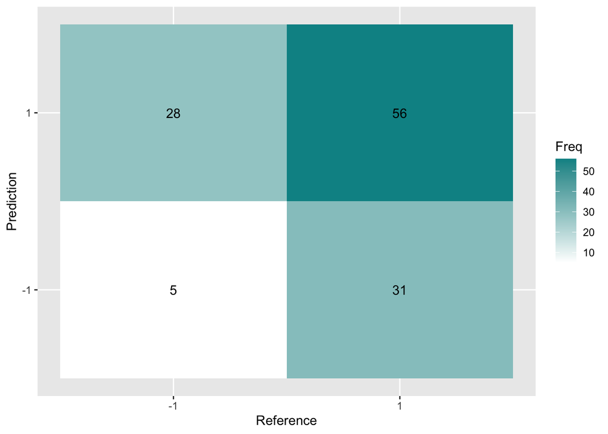

```r
plt_tree <- as.data.frame(cm_tree$table)
ggplot(plt_tree, aes(Reference, Prediction, fill = Freq)) +
  geom_tile() +
  geom_text(aes(label = Freq)) +
  scale_fill_gradient(low = "white", high = "#009194") +
  labs(x = "Reference", y = "Prediction") +
  scale_x_discrete(labels = c("-1", "1")) +
  scale_y_discrete(labels = c("-1", "1"))
```

# Discussion

At first, using Exploratory Data Analysis, I found out that across all 18 sessions,feeback type was more positive than negative which indicates that there were more success than failures. This means that the overall experiment was successful. In addition, I found the most active brain area across each session as well as the average spikes in each session and also displayed the count of the spikes. In the data integration part, I referenced the Project Demo and created a discussion variable using the 4 factors from contrast left and contrast right and included the average spikes and feedback_type. Instead of just focusing on one session, I utilized a for-loop to loop all 18 sessions to get the total feedback_type and the avg spikes across all trials. I then used these variables to train and test a logistic regression model and a confusion matrix as well using reference and prediction. Using the test data, it indicates that the prediction is off as the reference is right majority of times. I also added a decision tree and confusion matrix to compare the test data. Both predictiors are off however, the decision tree is closer than the logistic regression model. This could be because the variables such as the average spikes do not affect the feedback type that much.

# Reference

#GEEKSFORGEEKS: Exploratory Data Analysis In R #Discussion: Project Demo #Discussion: Logistic Regression #Lecture: Chapter 6: Prediction #CHATGPT: How to loop over multiple data sets #CHATGPT: Decision Trees

Steinmetz, N.A., Zatka-Haas, P., Carandini, M. et al. Distributed coding of choice, action and engagement across the mouse brain. Nature 576, 266–273 (2019). https://doi.org/10.1038/s41586-019-1787-x